# Coursework Report 201882

*N* removed NAs: 3

*N* removed typo: 1

*N* removed <18: 25

| Group | *N* | *M*<sub>age</sub> | *M*<sub>rating</sub> |
| --- | --- | --- | --- |
| Control | 57 | 21.23 | 5.51 |
| Experim | 64 | 21.08 | 6.84 |

**Main analysis results**

*t*(119) = -9.71, *p* < .001

[interactive chart not shown]

[figure not shown]

[interactive chart not shown]

# Coursework Report 201882

Analysing Data, Spring 2020

Table 1 *Descriptive Statistics by Age*

| Group | *M*<sub>age</sub> | *SD*<sub>age</sub> | Min | Max |
| --- | --- | --- | --- | --- |
| control | 21.23 | 2.20 | 18 | 27 |
| experimental | 21.05 | 1.77 | 18 | 26 |

```
## # A tibble: 122 x 5
## # Groups:   id [122]
##    id    question_1 question_2 question_3 attractiveness_comp
##    <fct>      <dbl>      <dbl>      <dbl>               <dbl>
##  1 QBVH           3          7          7                5.67
##  2 GNOM           4          6          5                5
##  3 TTJR           7          5          6                6
##  4 YEQY           6          7          5                6
##  5 GUSM           3          5          6                4.67
##  6 EQTY           7          6          3                5.33
##  7 YGBH           5          5          6                5.33
##  8 SSRP           3          7          5                5
##  9 SLWH           3          7          6                5.33
## 10 FNJK           5          8          6                6.33
## # ... with 112 more rows
```

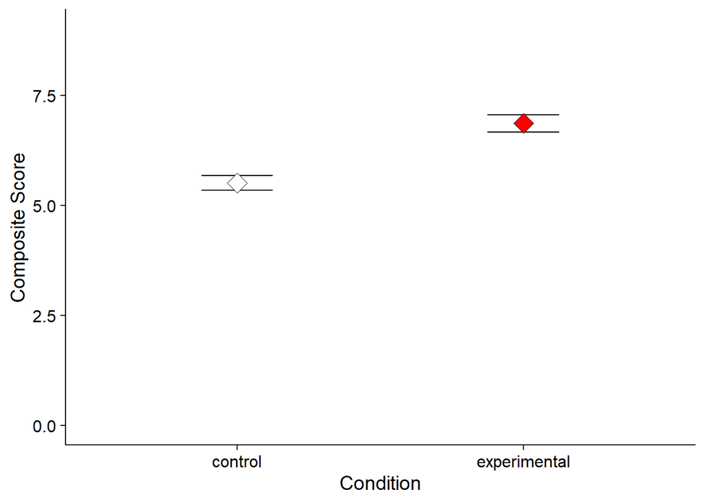

```
##
##  Two Sample t-test
##
## data:  attractiveness_comp by group
## t = -9.8233, df = 120, p-value < 0.00000000000000022
## alternative hypothesis: true difference in means is not equal to 0
## 95 percent confidence interval:
##  -1.625424 -1.080109
## sample estimates:
##      mean in group control mean in group experimental
##                   5.508772                   6.861538
```

# Methods

## Participants

150 female participants initially took part in this replication attempt. Three participants were removed from the data set because they did not provide their ages, while a further 25 participants were removed as they were under 18 years of age. The final number of participants who were included in the final results was 122. Participants were aged between 18-27, with a mean age of 21.13, a standard deviation of 1.97, and a range of 9.

Table 1 *Descriptive Statistics by Age*

| Group | *M*<sub>age</sub> | *SD*<sub>age</sub> | Min | Max |
| --- | --- | --- | --- | --- |
| control | 21.23 | 2.20 | 18 | 27 |
| experimental | 21.05 | 1.77 | 18 | 26 |

## Design

This study aimed to replicate Elliot et al’s (2010) study investigating if colour affects the perceived attractiveness of men by women. Colour was the independent variable and a categorical variable, and was tested by showing participants pictures of men standing in either a red (experimental condition) or a white (control) frame. Ratings of attractiveness were the dependent variable and a continuous variable, and was measured by asking participants three questions: “how attractive do you think this person is?”, “how pleasant is this person to look at?”, and “if I were to meet this person in this picture face to face, I would think he is attractive”. Participants had to answer these questions by rating how attractive they found the men in the pictures to be on a rating scale between 1 to 9, 1 being “not at all attractive” and 9 being “extremely attractive”. The operational hypothesis for this study was ’does seeing a picture of a man standing in either a red or a white coloured frame influence the mean ratings of attractiveness given by women on a rating scale of 1 to 9, 1 being “not at all attractive” and 9 being “extremely attractive”. The hypothesis was tested using a t-test.

# Results

This study investigated the prediction that colour would effect the perceived attractiveness of men by women using an independent measures t-test. This test showed that the means for both conditions showed a significant difference (*M*<sub>diff</sub> = -1.35, 95% CI [-1.63, -1.08]) and there was a significant difference between the two conditions on ratings of attractiveness (*t* (120) = -9.82, *p* = <.001. This means that overall the participants found the men standing in the red frame to be more attractive compared to the men standing in the white frame. Therefore, we can accept the alternative hypothesis.

# Discussion

This replication attempt of Elliot et al.’s (2010) study aimed to find out if the colour red has an effect on the perceived attractiveness of men by women. A t-test was carried out which found that participants gave the pictures of men in a red frame a mean attractiveness rating of 6.86, while the pictures of men in a white frame received a mean attractiveness rating of 5.5, suggesting that participants found the men in the red frame to be more attractive. Therefore this study supports Elliot et al.’s finding that the colour red does have an affect on attractiveness.

Many other studies have been conducted in this area of research with differing results. For example, Roberts et al., (2010) also found that men were judged to be more attractive by women when wearing the colour red. Many reasons been suggested as to why the colour red may increase attractiveness, including the idea that it signals a higher status (Mehta et al., 2008), or the idea that men themselves feel more attractive when wearing red and consequently change their posture or expressions in a way that women find more attractive (Roberts et al., 2010). However, other researchers such as Peperkoorn et al., (2016) have found the opposite effect, demonstrating that the colour red has no effect on ratings of attractiveness. Therefore, further research into this area seems to still be inconclusive.

A strength of this study is the scientific methods used to collect the data. As a questionnaire was used, this makes it easier to replicate the study as the methods are standardised. Therefore, the results can be checked and compared by other researchers to see if the same effect is found. A limitation with the design is that participants may have been able to easily guess the aim of the study. This is because the changes in the independent variable were made fairly obvious (red/white frame). Therefore, participants may have come up with an idea of the aim of the study and then answered the questions based on what they thought the researchers wanted to see. A further limitation is that we are unable to conclude from the data collected why the change in the independent variable had an affect on attractiveness ratings. further research could be conducted that uses a less obvious independent variable to make the aim of the study less obvious to participants.

In conclusion, this replication of Elliot et al’s.(2010) study found that female participants rated pictures of men standing in red frames as more attractive compared to men standing in white frames. This suggests that the colour red is linked to attractiveness. Further research should be conducted into this link to find out what mechanisms cause the colour red to have an affect on attraction.

# References

Elliot, A. J., Niesta Kayser, D., Greitemeyer, T., Lichtenfeld, S., Gramzow, R. H., Maier, M. A., & Liu, H. (2010). Red, rank, and romance in women viewing men. *Journal of Experimental Psychology: General, 139*(3), 399-417.

Mehta, P. H., Jones, A. C., & Josephs, R. A. (2008). The social endocrinology of dominance: basal testosterone predicts cortisol changes and behaviour following victory and defeat. *Journal of personality and social psychology, 94*(6), 1078.

Peperkoorn, L. S., Roberts, S. C., & Pollet, T. V. (2016). Revisiting the red effect on attractiveness and sexual receptivity: No effect of the color red on human mate preferences. Evolutionary Psychology, 14(4), 1474704916673841.

Roberts, S. C., Owen, R. C., & Havlicek, J. (2010). Distinguishing between perceiver and wearer effects in clothing colour-associated attributions. Evolutionary Psychology, 8, 350–364.